# Traveling Waves & Superposition: Active Learning Notes

## McEwen, © 2020

### version 2.0, 2025

**Note: These notes are a work in progress and may contain errors.**

**Copyright Notice:** These notes are the intellectual property of the author and may not be shared or distributed outside of the classroom without explicit permission. If you are an instructor interested in using these materials, please contact the author directly for permission.

These notes and exercises cover the basics of wave mechanics. They are not a substitute for your textbook, but rather provide a summary of key concepts along with exercises to prepare you for more challenging homework problems.

```python
import numpy as np
%matplotlib inline
import matplotlib.pyplot as plt
from matplotlib import animation
from IPython.display import HTML

from numpy import pi, sin, cos
from traveling_wave_funcs import plot_traveling_wave, traveling_wave, animate_wave, plot_super
from superposition_animations import animate_super, animate_interference
from beats import beat_plot

import base64
```

## What is $y(x,t)$?

The displacement $y(x,t)$ is the vertical position of the wave at position $x$ and time $t$. Since $y(x,t)$ depends on two variables, when we do our graphical analysis, we consider snapshots at different times to visualize it. This is done in Figures 1 and 2 below.

### Observing a Traveling Wave

What can we learn by observing a traveling wave?

First, we can measure the wavelength $\lambda$ by observing where the wave repeats in the $x$-direction. Mathematically, $y(x,t) = y(x + \lambda,t)$.

Second, we can pick a fixed point in the $x$-direction and measure the time for the wave to repeat itself. This is the period $T$, so $y(x,t) = y(x, t + T)$.

Third, we can measure the maximum vertical displacement of the wave. This is the amplitude $A$.

With the period and wavelength we can determine the [phase velocity](https://en.wikipedia.org/wiki/Phase_velocity) of the wave as

\begin{equation} v = \frac{\lambda}{T} = \lambda f. \end{equation}

### Mathematical Form of the Traveling Wave

The mathematical form of a sinusoidal traveling wave is

\begin{equation} y(x,t) = A \sin(kx - \omega t + \phi_0), \end{equation}

where $k = 2\pi/\lambda$ is the wave number, $\omega = 2\pi f = 2\pi/T$ is the angular frequency, and $\phi_0$ is the phase shift. The phase of the wave is $\phi = kx - \omega t + \phi_0$.

**Problem 1**

What are the units for $k$, $\lambda$, $\omega$, $f$, $T$, and $A$? For $k$, $\omega$, and $\phi_0$, you can determine the units by noting that the argument of the sine function in $y(x,t) = A \sin(kx - \omega t + \phi_0)$ must be dimensionless.

**Solution**

- $\lambda$: meters (m) - wavelength is a distance
- $A$: meters (m) - amplitude is a displacement
- $T$: seconds (s) - period is a time
- $f$: hertz (Hz) or s$^{-1}$ - frequency is inverse time
- $k$: radians per meter (rad/m) or m$^{-1}$ - since $kx$ must be dimensionless (in radians), $k$ has units of inverse length
- $\omega$: radians per second (rad/s) or s$^{-1}$ - since $\omega t$ must be dimensionless (in radians), $\omega$ has units of inverse time
- $\phi_0$: radians (rad) or dimensionless - phase shift is an angle

No part of the material moves in the $x$-direction. For example, if we excite traveling waves on a rope, segments of the rope only move vertically. Parts of the wave appear to move rightward because we track points at fixed vertical distance $y$. This is an example of a **transverse wave**, where the displacement is perpendicular to the direction of propagation.

**Problem 2**

What are examples of transverse waves and longitudinal waves?

**Solution**

**Transverse waves** (displacement perpendicular to propagation):

- Waves on a string or rope
- Electromagnetic waves (light, radio waves, X-rays)
- Water surface waves (approximately transverse)
- Seismic S-waves (secondary waves)

**Longitudinal waves** (displacement parallel to propagation):

- Sound waves in air, water, or solids
- Pressure waves
- Seismic P-waves (primary waves)
- Compression waves in a spring

### Figure 1

In Figure 1 we plot a traveling wave with no phase shift. The output has 6 panels.

The first 5 panels plot the wave at times $t = [0, T/4, T/2, 3T/4, T]$. A red dot and a green dot are tracked on the wave. The distance between them is one wavelength. The red and green dots are marked by keeping the vertical distance constant.

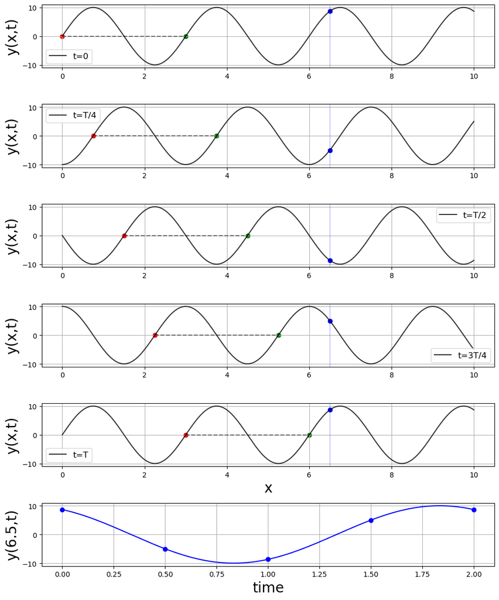

```python
plot_traveling_wave(10,2,3,0)
```

**Problem 3**

What is the amplitude $A$, wave number $k$, wavelength $\lambda$, angular frequency $\omega$, frequency $f$, and period $T$ of the traveling wave in Figure 1?

**Solution**

From Figure 1, we can read the following values:

- Amplitude: $A = 10$ (maximum vertical displacement)
- Wavelength: $\lambda = 3$ (distance for one complete cycle in space)
- Period: $T = 2$ (time for one complete cycle)
- Phase shift: $\phi_0 = 0$ (wave starts at zero at $x = 0$, $t = 0$)

From these, we can calculate:

- Wave number: $k = \frac{2\pi}{\lambda} = \frac{2\pi}{3} \approx 2.09$ rad/m
- Frequency: $f = \frac{1}{T} = \frac{1}{2} = 0.5$ Hz
- Angular frequency: $\omega = 2\pi f = \frac{2\pi}{2} = \pi \approx 3.14$ rad/s

### Fig 2.

Figure 2 is the same as figure 1, but now the phase angle is non-zero. Be sure to observe the simmilarities and difference between figures 1 and 2. The phase angle set the value of the displacement at $t=0$ and $x=0$.

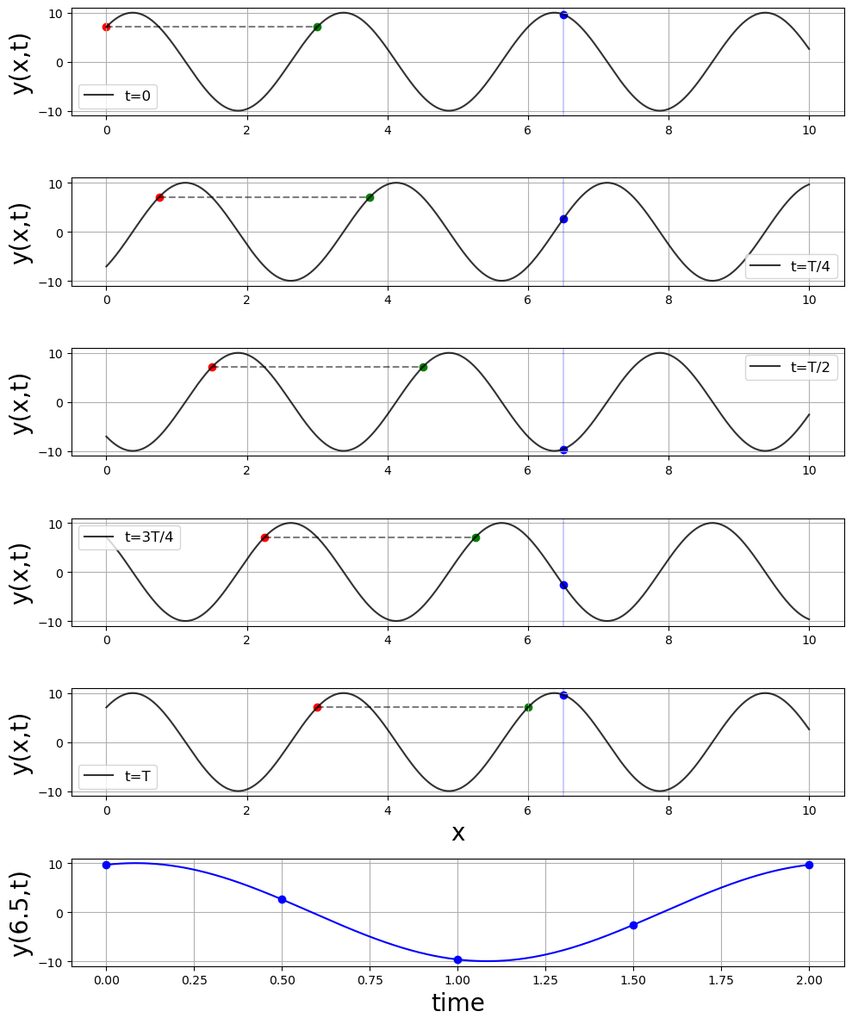

```python
plot_traveling_wave(10,2,3,pi/4)
```

## Building up the Mathematical Model

Imagine a long rope pulled taut. The left end is attached to a piston that moves up and down with amplitude $A$ and frequency $f$. (You can equally imagine your hand making small movements jiggling the rope end up and down.) We describe the vertical position of the left end as $y(x=0,t) = A \cos(\omega t)$. The movement of the left end excites a traveling wave on the rope that travels rightward along the rope. The frequency of the traveling wave equals the frequency of the source. This is a general phenomenon: the frequency of the disturbance equals the frequency of the source. In this case the source is the moving piston (or your hand).

**Problem 4**

How are $f$ and $\omega$ related?

**Solution**

The angular frequency $\omega$ and the frequency $f$ are related by

\begin{equation} \omega = 2\pi f. \end{equation}

This relationship comes from the fact that $\omega$ measures radians per unit time, while $f$ measures cycles per unit time. Since one complete cycle corresponds to $2\pi$ radians, we multiply $f$ by $2\pi$ to get $\omega$.

Equivalently,

\begin{equation} f = \frac{\omega}{2\pi}. \end{equation}

As the piston moves up and down, a traveling wave moves rightward on the rope. A traveling wave is periodic in both space and time. Therefore the displacement at position $x$ and time $t$ must equal the displacement at $x=0$ at some earlier time, $t_{\text{earlier}} = t - x/v$. You can see this in Figure 1 by following the red dot. The displacement marked by the red dot equals the displacement at $x=0$ at some earlier time. Considering this, we have $y(x,t) = y(0,t_{\text{earlier}}) = A \cos(\omega(t-x/v)) = A \cos(\omega t - \omega x/v)$. Defining $k = \omega/v$ or $v = \omega/k$, we have $y(x,t) = A \cos(\omega t - kx)$.

We can rewrite this as $y(x,t) = A \cos(-kx + \omega t) = A \cos(-(kx - \omega t))$. Since cosine is an even function, $\cos(-\theta) = \cos(\theta)$, so we have $y(x,t) = A \cos(kx - \omega t)$.

A phase shift can always be included. A phase shift sets the value of the cosine function at $t=0$ and $x=0$. We can also include a phase shift that swaps a cosine for a sine, since sines and cosines have the same shape but are shifted by $\pi/2$. So we can write our traveling wave expression as

\begin{equation} y(x,t) = A \cos(kx - \omega t + \phi_0). \end{equation}

Some books prefer a sine wave, which is just a matter of a phase shift,

\begin{equation} y(x,t) = A \sin(kx - \omega t + \phi_0). \end{equation}

The animation below shows a traveling wave with two points marked on it. The red dot marks a location of constant phase, where the phase is $\phi = kx - \omega t + \phi_0$. Since the red dot maintains constant phase, it follows a constant $y(x,t)$ value as the wave propagates. The motion of the red dot gives the impression that something is moving to the right. The blue dot marks a segment of the medium (perhaps one segment of the rope) at a fixed $x$-position. The blue dot only moves up and down, which is the only actual motion of the medium. Tracking the time it takes for the blue dot to return to its original location measures the period $T$.

### Phase Speed

In the animation, you can see that the red dot has velocity. This is the phase speed. The red dot marks a location of constant phase, $\phi = kx - \omega t + \phi_0 = \text{constant}$. We can derive the phase speed by differentiating

\begin{align} \begin{split} & \frac{d\phi}{dt} = k \frac{dx}{dt} - \omega = 0 \\ & \frac{dx}{dt} = \frac{\omega}{k} \\ & v = \frac{\omega}{k}, \end{split} \end{align}

where we defined the phase speed as $v = dx/dt$. We thus have the following important relationship.

\begin{equation} v = \frac{\omega}{k} = \lambda f \end{equation}

```python
anim=animate_wave(10,.5,4.3,pi/4)
#anim.save('traveling_wave.mp4')
HTML(anim.to_html5_video())
```

[video not shown]

## Superposition

Waves obey a superposition principle, that is waves add together to form a composite wave. Let us consider the superpostion of two waves, \begin{align} y(x,t)= y_1(x,t) + y_2(x,t), \end{align} where $y_1$ and $y_2$ are two traveling waves. The figures below shows snapshots of the superposition of two traveling waves. The first wave is colored blue, the second red, and the superposition of the two in black. These snapshots are at a fixed time. The horizontal axis represents the position $x$. We need to be sure that we understand that the superposition of the two waves means the resulting wave is the addition of the two waves at each point in space and time. To help you understand this, I have included a blue vertical line (I randomly selected a point in space). This way you can follow one specific point in space to see the addition.

**Superpostion Example 1: adding idential waves.**

Below is snapshot of the superpostion of two idential traveling waves. This is an example of what we call complete constructive interference.

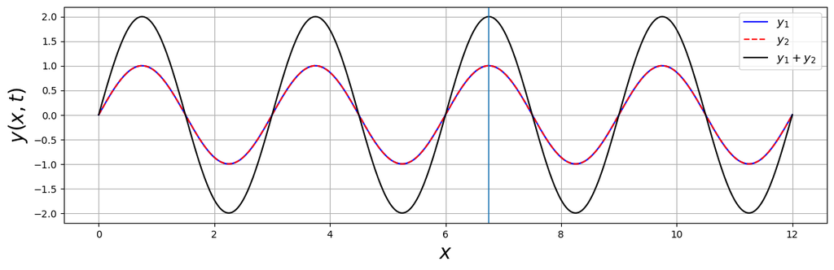

```python
plot_super(1,1,10,10,3,3,0,0)
```

**Superpostion Example 2: Complete Destructive Interference** Below is an example which one of the waves has a non-zero phase shift. This is an example of complete destructive interference.

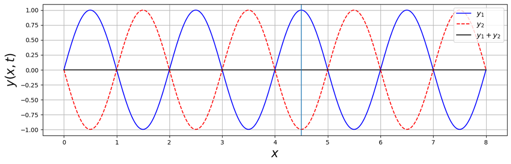

```python
plot_super(1,1,10,10,2,2,0,pi)
```

**Superposition Example 3: Wiggles for Fun**

Below is a more complicated example. We will talk about the details of an example like this latter in these notes.

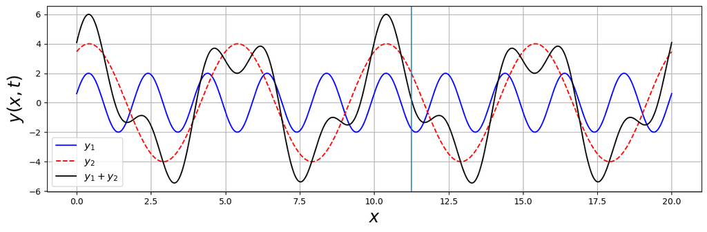

```python
plot_super(2,4,10,10,2,5,pi/10,pi/3)
```

## The Mathematics of Interference

### Interference from Identical Waves at Different Source Locations

Consider two traveling waves with the same amplitude $A$, wave number $k$, and angular frequency $\omega$. However, the sources need not be at the same location or have the same initial phase.

Let  
$x_1$: position of source 1  
$x_2$: position of source 2  
$\phi_{1,0}$, $\phi_{2,0}$: initial phases of sources 1 and 2, respectively.

We want to know what the resulting wave looks like at some observation point $x$.

The observer sees the superposition of the two waves:

\begin{align} \begin{split} y(t,x) &= y_1(t,x) + y_2(t,x) \\ &= A \sin[k(x - x_1) - \omega t + \phi_{1,0}] + A \sin[k(x - x_2) - \omega t + \phi_{2,0}]. \end{split} \end{align}

### Phase Difference and Path Difference

We can write the superposition of the waves as

\begin{align} y(t,x) &= y_1(t,x) + y_2(t,x) \\ &= A \left[ \sin(\Phi_1) + \sin(\Phi_2)\right], \end{align}

where $\Phi_1 = k(x- x_1) - \omega t + \phi_{1,0}$ and $\Phi_2 = k(x - x_2) - \omega t + \phi_{2,0}$. The phase difference is $\Delta \Phi = \Phi_2 - \Phi_1$,

\begin{equation} \Delta \Phi = k(x_2 - x_1) + (\phi_{2,0} - \phi_{1,0}). \end{equation}

If the two sources have the same initial phase, $\phi_{1,0} = \phi_{2,0}$, and are separated by $d = x_2 - x_1$, then

\begin{equation} \Delta \Phi = k d = \frac{2\pi d}{\lambda}. \end{equation}

If the sources have an initial phase difference $\Delta \phi_0 = \phi_{2,0} - \phi_{1,0}$ and are separated by $d = x_2 - x_1$, then

\begin{equation} \Delta \Phi = k d + \Delta \phi_0 = \frac{2\pi d}{\lambda} + \Delta \phi_0. \end{equation}

### Conditions for Interference

If the two waves at the observation point are **in phase** (their phase difference is a multiple of $2\pi$), they interfere constructively. If their phase difference is an odd multiple of $\pi$, they interfere destructively. Mathematically, we can see this by noting that $\sin(\theta + 2\pi m) = \sin(\theta)$ and $\sin(\theta + \pi m) = (-1)^m\sin(\theta)$ for $m = 1, 2, 3, \dots$. Thus, we have the following conditions for constructive and destructive interference.

Complete constructive interference occurs when

\begin{equation} \Delta \Phi = 2\pi n, \quad n = 0, 1, 2, \dots \end{equation}

giving maximum amplitude $2A$.

Complete destructive interference occurs when

\begin{equation} \Delta \Phi = (2n + 1)\pi, \quad n = 0, 1, 2, \dots \end{equation}

giving amplitued $A=0$.

### Examples of Sources at Different Locations

Below are examples where the two sources emitting the waves are at different locations. The source locations are marked as red and blue vertical lines, and their corresponding waves are colored red and blue. The superposition of the red and blue source waves is shown in black.

```python
print("Neither fully constructive or fully destructive interference.")
k=2
omega=2
x1=0
x2=-4
phi1=0
phi2=0
anim=animate_interference(10,k,omega,x1,x2,phi1,phi2)
HTML(anim.to_html5_video())
```

```
Neither fully constructive or fully destructive interference.
```

[video not shown]

```python
print("An example of fully destructive interference.")
k=2
omega=2
x1=0
x2=-3.7
dx=x2-x1
phi1=0
phi2=pi+k*dx
anim=animate_interference(10,k,omega,x1,x2,phi1,phi2)
HTML(anim.to_html5_video())
```

```
An example of fully destructive interference.
```

[video not shown]

```python
print("An example of fully constructive interference.")
k=2
omega=2
x1=0
x2=-3.7
dx=x2-x1
phi1=0
phi2=2*pi+k*dx
anim=animate_interference(10,k,omega,x1,x2,phi1,phi2)
HTML(anim.to_html5_video())
```

```
An example of fully constructive interference.
```

[video not shown]

### Problems

**Problem 5**  
Show that if the initial phase difference is zero, i.e., $\phi_{1,0} = \phi_{2,0}$, then the waves show constructive interference when $d = m\lambda$ and destructive interference for $d = (m + 1/2)\lambda$ for $m = 0, 1, 2, \dots$.

**Hint**

Start with the phase difference formula and substitute $\phi_{1,0} = \phi_{2,0}$. Given this, what is the condition, mentioned above, for destrucitve interference?

**Solution**

With $\phi_{1,0} = \phi_{2,0}$, the phase difference becomes

\begin{equation} \Delta \Phi = kd = \frac{2\pi d}{\lambda}. \end{equation}

For constructive interference, we require $\Delta \Phi = 2\pi m$ where $m = 0, 1, 2, \dots$. This gives

\begin{equation} \frac{2\pi d}{\lambda} = 2\pi m, \end{equation}

which simplifies to

\begin{equation} d = m\lambda, \quad m = 0, 1, 2, \dots \end{equation}

For destructive interference, we require $\Delta \Phi = (2n + 1)\pi$ where $n = 0, 1, 2, \dots$. This gives

\begin{equation} \frac{2\pi d}{\lambda} = (2n + 1)\pi, \end{equation}

which simplifies to

\begin{equation} d = \left(n + \frac{1}{2}\right)\lambda, \quad n = 0, 1, 2, \dots \end{equation}

Setting $m = n$ completes the proof.

**Problem 6**

Suppose $\Delta \phi_0 = 0$ and $\lambda = 10$ m. What is the minimum nonzero value of $d$ (the separation between sources) for which the two waves will constructively interfere at some observation point? Find another nonzero value of $d$ that also produces constructive interference.

**Hint**

**Solution**

For constructive interference with $\Delta \phi_0 = 0$,

\begin{equation} \frac{2\pi d}{\lambda} = 2\pi m, \end{equation}

which gives

\begin{equation} d = m\lambda. \end{equation}

For the minimum nonzero separation, use $m = 1$:

\begin{equation} d = 10~\text{m}. \end{equation}

Another value that produces constructive interference uses $m = 2$:

\begin{equation} d = 20~\text{m}. \end{equation}

Minimum nonzero separation: $d = 10$ m  
Another value: $d = 20$ m

### Sound Wave Interference

Sound waves are pressure disturbances that travel through a medium like air, water, or solids. A sound source, such as a vibrating speaker, creates these waves by causing areas of higher pressure (compressions) and lower pressure (rarefactions) that propagate outward.

When the source vibrates, it pushes on the surrounding medium, creating a compression (a region of high pressure). When it moves back, it creates a rarefaction (a region of low pressure). You can think of the loudspeaker diaphragm moving back and forth, pushing the air and then relaxing the push.

These compressions and rarefactions travel through the medium as a wave, transferring energy from the source to other particles. The particles themselves oscillate around their equilibrium positions, but the disturbance (the wave) moves forward.

This continuous cycle of high and low pressure is what our ears detect as sound. The frequency of these pressure changes is interpreted by our brains as pitch: higher frequency yields higher pitch, lower frequency yields lower pitch.

In the following problems, we consider interference of sound waves. Sound waves travel in air at approximately $v = 340$ m/s.

**Problem 7**

Two speakers emit sound waves in phase at a frequency of 340 Hz. Speaker 1 is located at $x_1 = 0$ m and speaker 2 is located at $x_2 = 5$ m. An observer is positioned at $x = 15$ m. Determine whether the observer experiences constructive or destructive interference.

**Hint**

Find the wavelength first, then calculate the path difference between the two speakers and the observer.

**Solution**

First, we find the wavelength using $v = f\lambda$: \begin{equation} \lambda = \frac{v}{f} = \frac{340~\text{m/s}}{340~\text{Hz}} = 1~\text{m}. \end{equation}

The path difference is the difference in distances from each speaker to the observer: \begin{equation} \Delta r = |x - x_1| - |x - x_2| = 15~\text{m} - 10~\text{m} = 5~\text{m}. \end{equation}

Since the speakers emit in phase, the phase difference is \begin{equation} \Delta \Phi = \frac{2\pi \Delta r}{\lambda} = \frac{2\pi (5~\text{m})}{1~\text{m}} = 10\pi. \end{equation}

Since $\Delta \Phi = 10\pi = 2\pi(5)$, which is an integer multiple of $2\pi$, the observer experiences constructive interference.

**Problem 8**

Two speakers are positioned at points A and B, separated by a distance of 6 m. A listener is located at point C such that points A, B, and C form a right triangle with the right angle at B. The distance from B to C is 8 m. Both speakers emit sound waves in phase at a frequency of 425 Hz. Determine whether the listener experiences constructive or destructive interference.

**Hint**

Sound waves from each speaker travel outward in all directions. To determine the interference pattern at the listener's position, you need to find the path length difference—that is, the difference in distances the sound travels from each speaker to reach the listener. Use the Pythagorean theorem to calculate the distance from speaker A to the listener at point C, then compare this to the known distance from speaker B to point C.

**Solution**

First, we find the wavelength:

\begin{equation} \lambda = \frac{v}{f} = \frac{340~\text{m/s}}{425~\text{Hz}} = 0.8~\text{m}. \end{equation}

Next, we find the distances from each speaker to the listener. The distance from B to C is given as $r_B = 8$ m. Using the Pythagorean theorem for the right triangle,

\begin{equation} r_A = \sqrt{(6~\text{m})^2 + (8~\text{m})^2} = \sqrt{36 + 64} = \sqrt{100} = 10~\text{m}. \end{equation}

The path difference is

\begin{equation} \Delta r = r_A - r_B = 10~\text{m} - 8~\text{m} = 2~\text{m}. \end{equation}

The phase difference is

\begin{equation} \Delta \Phi = \frac{2\pi \Delta r}{\lambda} = \frac{2\pi (2~\text{m})}{0.8~\text{m}} = 5\pi. \end{equation}

Since $\Delta \Phi = 5\pi$, which is an odd multiple of $\pi$ (or equivalently, $(2n+1)\pi$ where $n=2$), the listener experiences destructive interference.

```python
with open('speaker_interference_pattern.png', 'rb') as image_file:
    encoded = base64.b64encode(image_file.read()).decode()
    #print(f'<img src="data:…" alt="Speaker Interference Pattern">')
```

**Problem 9: Two-Speaker Interference Pattern** The diagram below shows two speakers (Speaker 1 in blue, Speaker 2 in red) separated by 4 meters, both emitting sound waves in phase at the same frequency. The concentric circles represent wave crests emanating from each speaker. Sound travels at $v = 340$ m/s in air.

[figure not shown]

Five observation points (A, B, C, D, and E) are marked on the diagram.

**(a)** By examining the diagram, estimate the wavelength of the sound waves.

**(b)** Calculate the frequency of the sound waves.

**(c)** For each of the five points (A, B, C, D, and E), determine whether a listener at that location would experience **constructive interference** (loud sound) or **destructive interference** (quiet sound or silence). You can make this determination by visual inspection: look at whether the waves from the two speakers arrive in phase (both crests or both troughs align) or out of phase (a crest from one speaker meets a trough from the other).

**(d)** Choose one point from part (c) and verify your answer quantitatively by calculating the path difference $\Delta r = |r_1 - r_2|$ from each speaker to that point.

**Recall:**

- **Constructive interference** occurs when waves arrive **in phase**: two crests align, or two troughs align. Mathematically, this happens when the path difference $\Delta r = n\lambda$ (integer multiple of wavelength).
- **Destructive interference** occurs when waves arrive **out of phase**: a crest from one speaker meets a trough from the other. Mathematically, this happens when the path difference $\Delta r = (n + \frac{1}{2})\lambda$ (half-integer multiple of wavelength).

**Hint for part (a)**

Look at the spacing between consecutive wave crests from either speaker. The distance between adjacent crests is one wavelength.

**Hint for part (c)**

The circles are the crests; midway between them is a trough. You need to look for places where crests align with crests or troughs align with troughs for constructive interference. Places where troughs align with crests are locations of destructive interference.

**Hint for part (d)**

Use the Pythagorean theorem to calculate distances: $r = \sqrt{(x - x_{\text{speaker}})^2 + (y - y_{\text{speaker}})^2}$.

The speakers are located at $(-2, 0)$ and $(2, 0)$.

**Solution**

**(a) Finding the wavelength:**

By examining the diagram, consecutive wave crests from either speaker are separated by 2 meters. Therefore:

$$\lambda = 2 \text{ m}$$

**(b) Finding the frequency:**

Using the wave equation $v = f\lambda$:

$$f = \frac{v}{\lambda} = \frac{340 \text{ m/s}}{2 \text{ m}} = 170 \text{ Hz}$$

**(c) Visual determination of interference:**

**Point A at (0, 4): Constructive interference** (loud).

**Point B at (6, 0): Constructive interference** (loud).

**Point C at (0, 7): Constructive interference** (loud).

**Point D at (3.5, 2): Destructive interference** (quiet).

**Point E at (4.5, 4): Destructive interference** (quiet).

**(d) Quantitative verification - Example with Point B:**

**Speaker positions:** Speaker 1 at $(-2, 0)$ m, Speaker 2 at $(2, 0)$ m.

**Point B at (6, 0):**

$r_1 = \sqrt{(6-(-2))^2 + (0-0)^2} = \sqrt{64} = 8$ m

$r_2 = \sqrt{(6-2)^2 + (0-0)^2} = \sqrt{16} = 4$ m

$\Delta r = |r_1 - r_2| = 4$ m $= 2\lambda$

Since the path difference is exactly 2 wavelengths (an integer multiple), this confirms **constructive interference**.

*You could verify any of the other points similarly using the Pythagorean theorem.*

## Modulation of the Amplitude

What happens if we don't have complete constructive or destructive interference? Let's work through the full mathematics of this situation:

\begin{align} \begin{split} y &= y_1 + y_2 \\ &= A \sin[k(x - x_1) - \omega t + \phi_{1,0}] + A \sin[k(x - x_2) - \omega t + \phi_{2,0}]. \end{split} \end{align}

**Problem 10**

Use the trigonometric identity $\sin \alpha + \sin \beta = 2 \cos\left[\frac{1}{2}(\alpha - \beta)\right] \sin\left[\frac{1}{2}(\alpha +\beta)\right]$ to show that

\begin{equation} y = \left[ 2A \cos\left( \frac{\Delta \phi}{2}\right) \right]\sin[k(x - x_{\text{avg}}) - \omega t + \phi_{0,\text{avg}}], \end{equation}

where $x_{\text{avg}} = (x_1 + x_2)/2$ and $\phi_{0,\text{avg}} = (\phi_{1,0} + \phi_{2,0})/2$.

**Hint**

Identify $\alpha$ and $\beta$ with the arguments of the two sine functions, then compute $\alpha - \beta$ and $\alpha + \beta$.

**Solution**

Starting with

\begin{equation} y = A \sin[k(x - x_1) - \omega t + \phi_{1,0}] + A \sin[k(x - x_2) - \omega t + \phi_{2,0}], \end{equation}

let

- $\alpha = k(x - x_1) - \omega t + \phi_{1,0}$
- $\beta = k(x - x_2) - \omega t + \phi_{2,0}$

Calculate $\alpha - \beta$:

\begin{equation} \alpha - \beta = k(x - x_1) - k(x - x_2) + \phi_{1,0} - \phi_{2,0} = k(x_2 - x_1) + (\phi_{1,0} - \phi_{2,0}) = -k\Delta x - \Delta\phi_0 = -\Delta\phi. \end{equation}

Calculate $\alpha + \beta$:

\begin{equation} \alpha + \beta = k(x - x_1) + k(x - x_2) - 2\omega t + \phi_{1,0} + \phi_{2,0} = 2k(x - x_{\text{avg}}) - 2\omega t + 2\phi_{0,\text{avg}}. \end{equation}

Apply the identity:

\begin{equation} y = A \cdot 2\cos\left(\frac{-\Delta\phi}{2}\right)\sin\left(k(x - x_{\text{avg}}) - \omega t + \phi_{0,\text{avg}}\right). \end{equation}

Since $\cos(-\theta) = \cos(\theta)$,

\begin{equation} y = 2A\cos\left(\frac{\Delta\phi}{2}\right)\sin[k(x - x_{\text{avg}}) - \omega t + \phi_{0,\text{avg}}]. \end{equation}

We can consider the composite amplitude to be

\begin{equation} A_{\text{composite}} = 2A \cos\left(\frac{\Delta \phi}{2}\right). \end{equation}

### Intensity of Interfering Waves

The intensity of a wave is proportional to the square of its amplitude. For a single wave with amplitude $A$, the intensity is $I_0 \propto A^2$. When two waves interfere, the resulting intensity depends on the composite amplitude.

From our previous result, the composite amplitude is

\begin{equation} A_{\text{composite}} = 2A\cos\left(\frac{\Delta\phi}{2}\right). \end{equation}

The intensity of the superposed waves is proportional to the square of the composite amplitude:

\begin{equation} I = I_0 \left[2\cos\left(\frac{\Delta\phi}{2}\right)\right]^2 = 4I_0\cos^2\left(\frac{\Delta\phi}{2}\right). \end{equation}

Using the trigonometric identity $\cos^2(\theta) = \frac{1 + \cos(2\theta)}{2}$, we can rewrite this as

\begin{equation} I = 4I_0 \cdot \frac{1 + \cos(\Delta\phi)}{2} = 2I_0[1 + \cos(\Delta\phi)]. \end{equation}

This shows that:

- For constructive interference ($\Delta\phi = 2\pi m$), $\cos(\Delta\phi) = 1$, giving $I = 4I_0$ (maximum intensity)
- For destructive interference ($\Delta\phi = (2m+1)\pi$), $\cos(\Delta\phi) = -1$, giving $I = 0$ (minimum intensity)
- For intermediate phase differences, the intensity varies smoothly between these extremes

**Problem 11**

Two speakers are separated by 2 m and emit sound waves in phase at a frequency of 170 Hz. A listener is located 10 m from one speaker and 12 m from the other. If each speaker alone produces an intensity of $I_0 = 1.0 \times 10^{-6}$ W/m² at the listener's position, what is the total intensity at the listener's location when both speakers are operating?

**Hint**

Calculate the phase difference from the path difference, then use the intensity formula for interfering waves.

**Solution**

First, find the wavelength:

\begin{equation} \lambda = \frac{v}{f} = \frac{340~\text{m/s}}{170~\text{Hz}} = 2~\text{m}. \end{equation}

The path difference is

\begin{equation} \Delta r = 12~\text{m} - 10~\text{m} = 2~\text{m}. \end{equation}

The phase difference is

\begin{equation} \Delta\phi = \frac{2\pi\Delta r}{\lambda} = \frac{2\pi(2~\text{m})}{2~\text{m}} = 2\pi. \end{equation}

Using the intensity formula for interfering waves:

\begin{equation} I = 2I_0[1 + \cos(\Delta\phi)] = 2(1.0 \times 10^{-6}~\text{W/m}^2)[1 + \cos(2\pi)] = 2(1.0 \times 10^{-6}~\text{W/m}^2)[1 + 1] = 4.0 \times 10^{-6}~\text{W/m}^2. \end{equation}

The total intensity is $4.0 \times 10^{-6}$ W/m², which is four times the intensity of a single speaker (constructive interference).

### Sound Intensity and Decibels

The human ear can detect an enormous range of sound intensities, from the faintest whisper to the roar of a jet engine. Because this range spans many orders of magnitude (from about $10^{-12}$ W/m² to over 1 W/m²), we use a logarithmic scale called the decibel scale.

The sound level $\beta$ in decibels (dB) is defined as

\begin{equation} \beta = 10\log_{10}\left(\frac{I}{I_0}\right), \end{equation}

where $I$ is the intensity of the sound and $I_0 = 1.0 \times 10^{-12}$ W/m² is the reference intensity, approximately the threshold of human hearing at 1000 Hz.

Some properties of the decibel scale:

- An increase of 10 dB corresponds to a tenfold increase in intensity
- An increase of 3 dB (more precisely, 3.01 dB) corresponds to a doubling of intensity
- The threshold of hearing is 0 dB
- Normal conversation is about 60 dB
- A rock concert can reach 110-120 dB
- Sounds above 85 dB can cause hearing damage with prolonged exposure

**Problem 12**

A single speaker produces a sound level of 80 dB at a certain location. When a second identical speaker is added at the same location and both speakers operate in phase, what is the new sound level in decibels?

**Hint**

When two identical sources operate in phase at the same location, the amplitudes add, so the intensity quadruples.

**Solution**

First, find the intensity $I_1$ of the single speaker. From the definition of decibels:

\begin{equation} 80 = 10\log_{10}\left(\frac{I_1}{I_0}\right). \end{equation}

Solving for $I_1$:

\begin{equation} 8 = \log_{10}\left(\frac{I_1}{I_0}\right), \end{equation}

\begin{equation} I_1 = I_0 \times 10^8. \end{equation}

When two identical speakers operate in phase at the same location, the amplitudes add, so $A_{\text{total}} = 2A$. Since intensity is proportional to amplitude squared, the new intensity is

\begin{equation} I_2 = 4I_1 = 4I_0 \times 10^8. \end{equation}

The new sound level is

\begin{equation} \beta_2 = 10\log_{10}\left(\frac{I_2}{I_0}\right) = 10\log_{10}\left(\frac{4I_0 \times 10^8}{I_0}\right) = 10\log_{10}(4 \times 10^8). \end{equation}

\begin{equation} \beta_2 = 10[\log_{10}(4) + \log_{10}(10^8)] = 10[0.602 + 8] = 10(8.602) = 86.02~\text{dB}. \end{equation}

The new sound level is approximately 86 dB, an increase of about 6 dB from the single speaker.

Note: Doubling the intensity (not the amplitude) increases the sound level by 3 dB, but doubling the amplitude (which quadruples the intensity) increases it by 6 dB.

## Power and Intensity

Power is the rate at which energy is transferred by the wave, $P = dE/dt$. Intensity is the amount of power per area as \begin{align} I = \frac{P}{A}. \end{align}

If we assume the wave is spherical, emitting in all directions, then we can compute the intensity at a distance $r$ from the source by drawing a spherical shell of radius $r$ around the source and accounting for the shell's area, $4 \pi r^2$, as \begin{align} I = \frac{P}{4 \pi r^2}. \end{align}

**Problem 13**

You are standing a distance of $r_1$ from a source emitting waves in all directions. You move to a distance $r_2 = 3r_1$. By what factor does the intensity increase or decrease (or perhaps remain the same)?

**Hint**

Use the inverse square law for intensity. Compare the ratio $I_2/I_1$.

**Solution**

The intensity at distance $r_1$ is \begin{equation} I_1 = \frac{P}{4\pi r_1^2}. \end{equation}

The intensity at distance $r_2 = 3r_1$ is \begin{equation} I_2 = \frac{P}{4\pi r_2^2} = \frac{P}{4\pi (3r_1)^2} = \frac{P}{4\pi \cdot 9r_1^2} = \frac{1}{9} \cdot \frac{P}{4\pi r_1^2} = \frac{I_1}{9}. \end{equation}

The intensity decreases by a factor of 9. When you triple your distance from the source, the intensity drops to 1/9 of its original value.

Often, when intensity is computed, we take the time averaged power as \begin{equation} \left< P \right> = \frac{1}{T} \int_0^T P(t) \, dt, \end{equation} the average power over one cycle.

Note, be careful about the bracket symbols, they are often used for many forms of average: time average, spatial average, etc. Use context to make the conclusion.

**Problem 14**

Appealing to the Riemann sum definition of the integral, verify that the time average power formula above is the time average in the sense that you are most familiar with an average, i.e., add up all the parts and divide by the number of parts.

**Hint**

Recall that the Riemann sum approximates an integral as $\int_0^T f(t) \, dt \approx \sum_{i=1}^{N} f(t_i) \Delta t$, where $\Delta t = T/N$.

**Solution**

The Riemann sum definition of the integral is \begin{equation} \int_0^T P(t) \, dt = \lim_{N \to \infty} \sum_{i=1}^{N} P(t_i) \Delta t, \end{equation} where $\Delta t = T/N$ is the width of each subinterval and $t_i$ are sample points.

Substituting this into the time average formula gives \begin{equation} \left< P \right> = \frac{1}{T} \int_0^T P(t) \, dt = \frac{1}{T} \lim_{N \to \infty} \sum_{i=1}^{N} P(t_i) \Delta t = \lim_{N \to \infty} \frac{1}{T} \sum_{i=1}^{N} P(t_i) \frac{T}{N}. \end{equation}

Simplifying: \begin{equation} \left< P \right> = \lim_{N \to \infty} \frac{1}{N} \sum_{i=1}^{N} P(t_i). \end{equation}

This is exactly the familiar definition of an average: sum all the values and divide by the number of values. The integral generalizes this to the continuous case where $N \to \infty$.

---

**Problem 15**

Two coherent sources create an interference pattern; source 1 is at location $x_1$ and source 2 is at location $x_2$. At a point P, the waves from each source arrive as $y_1(x,t) = A\sin(k(x-x_1) - \omega t + \phi)$ and $y_2(x,t) = A\sin(k(x-x_2) - \omega t + \phi)$. The total displacement is $y(x,t) = y_1(x,t) + y_2(x,t)$. The intensity is proportional to the time-averaged square of the displacement, $I \propto \langle y^2(x,t) \rangle$. Find the time-averaged intensity $\langle I \rangle$ as a function of the phase difference, expressing your answer in terms of $I_0$, the intensity from a single source.

**Hint**

The phase difference between the two waves comes from the path difference: $\Delta\phi = k(x-x_1) - k(x-x_2) = k(x_2 - x_1)$. Use the trigonometric identity $\sin(\alpha) + \sin(\beta) = 2\sin\left(\frac{\alpha + \beta}{2}\right)\cos\left(\frac{\alpha - \beta}{2}\right)$ to add the waves. Then square the result and take the time average. Remember that $\langle \sin^2(\omega t + \text{const}) \rangle = 1/2$.

**Solution**

The total displacement is \begin{equation} y(x,t) = A\sin(k(x-x_1) - \omega t + \phi) + A\sin(k(x-x_2) - \omega t + \phi). \end{equation}

The phase difference between the two waves is \begin{equation} \Delta\phi = k(x-x_1) - k(x-x_2) = k(x_2 - x_1). \end{equation}

Using the trigonometric identity $\sin(\alpha) + \sin(\beta) = 2\sin\left(\frac{\alpha + \beta}{2}\right)\cos\left(\frac{\alpha - \beta}{2}\right)$ with $\alpha = k(x-x_1) - \omega t + \phi$ and $\beta = k(x-x_2) - \omega t + \phi$, we get \begin{equation} y(x,t) = 2A\sin\left(k\left(x-\frac{x_1+x_2}{2}\right) - \omega t + \phi\right)\cos\left(\frac{\Delta\phi}{2}\right). \end{equation}

The intensity is proportional to $y^2(x,t)$, so \begin{equation} I \propto y^2(x,t) = 4A^2\sin^2\left(k\left(x-\frac{x_1+x_2}{2}\right) - \omega t + \phi\right)\cos^2\left(\frac{\Delta\phi}{2}\right). \end{equation}

Taking the time average and using $\langle \sin^2(\omega t + \text{const}) \rangle = 1/2$, we find \begin{equation} \langle I \rangle \propto 4A^2 \cdot \frac{1}{2} \cdot \cos^2\left(\frac{\Delta\phi}{2}\right) = 2A^2\cos^2\left(\frac{\Delta\phi}{2}\right). \end{equation}

Since the intensity from a single source is $I_0 \propto A^2 \cdot 1/2$, we can write \begin{equation} \langle I \rangle = 2I_0\left[2\cos^2\left(\frac{\Delta\phi}{2}\right)\right] = 4I_0\cos^2\left(\frac{\Delta\phi}{2}\right). \end{equation}

Using the identity $\cos^2(\Delta\phi/2) = (1 + \cos\Delta\phi)/2$, this can be written as \begin{equation} \langle I \rangle = 2I_0(1 + \cos\Delta\phi). \end{equation}

This shows that the intensity varies from $4I_0$ (constructive interference, $\Delta\phi = 0, 2\pi, 4\pi, \ldots$) to $0$ (destructive interference, $\Delta\phi = \pi, 3\pi, 5\pi, \ldots$).

**Problem 16**

From Problem 15, we found that constructive interference occurs when $\Delta\phi = 0, 2\pi, 4\pi, \ldots$ and destructive interference occurs when $\Delta\phi = \pi, 3\pi, 5\pi, \ldots$. Recall that the phase difference is $\Delta\phi = k(x_2 - x_1)$, where $k = 2\pi/\lambda$ is the wave number. Let $\Delta x = |x_2 - x_1|$ be the path difference between the two sources.

(a) What is the relationship between $\Delta x$ and $\lambda$ for constructive interference?

(b) What is the relationship between $\Delta x$ and $\lambda$ for destructive interference?

**Hint**

Substitute $k = 2\pi/\lambda$ into the phase difference $\Delta\phi = k\Delta x$ and solve for $\Delta x$ using the conditions for constructive and destructive interference.

**Solution**

The phase difference is \begin{equation} \Delta\phi = k\Delta x = \frac{2\pi}{\lambda}\Delta x. \end{equation}

**(a) Constructive interference:**

For constructive interference, $\Delta\phi = 0, 2\pi, 4\pi, \ldots = 2\pi m$ where $m = 0, 1, 2, 3, \ldots$

Substituting: \begin{equation} \frac{2\pi}{\lambda}\Delta x = 2\pi m. \end{equation}

Solving for $\Delta x$: \begin{equation} \Delta x = m\lambda, \quad m = 0, 1, 2, 3, \ldots \end{equation}

Constructive interference occurs when the path difference is an integer multiple of the wavelength.

**(b) Destructive interference:**

For destructive interference, $\Delta\phi = \pi, 3\pi, 5\pi, \ldots = (2m+1)\pi$ where $m = 0, 1, 2, 3, \ldots$

Substituting: \begin{equation} \frac{2\pi}{\lambda}\Delta x = (2m+1)\pi. \end{equation}

Solving for $\Delta x$: \begin{equation} \Delta x = \left(m + \frac{1}{2}\right)\lambda, \quad m = 0, 1, 2, 3, \ldots \end{equation}

Destructive interference occurs when the path difference is an odd multiple of half-wavelengths.

## Beats

We now consider the case in which the frequencies are not the same, but the sources are at the same location $x_1 = x_2 = 0$, and we consider the waves to have the same phase shifts $\phi_{1,0} = \phi_{2,0} = 0$:

\begin{equation} y = A\sin(kx - \omega_1 t) + A\sin(kx - \omega_2 t). \end{equation}

**Problem 17**

Using the same trigonometric identity as before, show that the superposition of the two waves is given by

\begin{equation} y = 2A\cos(\omega_{\text{mod}} t)\sin(kx - \omega_{\text{avg}} t), \end{equation}

where $\omega_{\text{mod}} = |\omega_1 - \omega_2|/2$ and $\omega_{\text{avg}} = (\omega_1 + \omega_2)/2$ (mod stands for modulation).

**Hint**

**Solution**

Starting with

\begin{equation} y = A\sin(kx - \omega_1 t) + A\sin(kx - \omega_2 t), \end{equation}

let

- $\alpha = kx - \omega_1 t$
- $\beta = kx - \omega_2 t$

Calculate $\alpha - \beta$:

\begin{equation} \alpha - \beta = -\omega_1 t + \omega_2 t = (\omega_2 - \omega_1)t. \end{equation}

Here is an example plot of a beat.

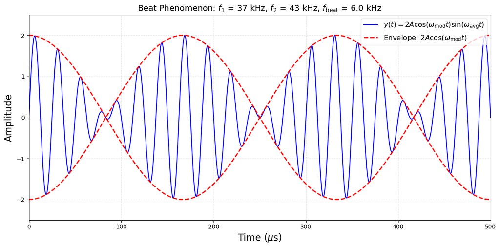

```python
beat_plot()
```

## Examples

Below are a set of examples of the superpostion principle at play. There are two traveling waves colored in blue and red. The superposition of the two waves is in black.

### standing wave

A standing wave is composed of two traveling waves moving in opposite directions. Consider two waves with the same amplitude $A$, wave number $k$, and angular frequency $\omega$, but traveling in opposite directions:

\begin{align} \begin{split} y &= y_1 + y_2 \\ &= A\sin(kx - \omega t) + A\sin(-kx - \omega t) \\ &= A\sin(kx - \omega t) + A\sin[-(kx + \omega t)] \end{split} \end{align}

The first wave $y_1 = A\sin(kx - \omega t)$ travels in the positive $x$-direction (to the right), while the second wave $y_2 = A\sin(-kx - \omega t)$ travels in the negative $x$-direction (to the left). These waves are identical except for the direction of their velocity: one has velocity $+v = +\omega/k$ and the other has velocity $-v = -\omega/k$.

Observe how the blue and red waves move in opposite directions. Observe how the black wave (their superposition) appears to have zero velocity—it oscillates in place rather than propagating.

```python
# standing wave example
phi1=0
phi2=0

lam1=1
lam2=1
k1=2*pi/lam1
k2=2*pi/lam2

w1=5
w2=-5

a1=10
a2=10
anim=animate_super(a1,a2,k1,k2,w1,w2,phi1,phi2)
HTML(anim.to_html5_video())
```

[video not shown]

### destructive interference

We can have two traveling waves with a phase shift difference of $\pi$ to get complete destructive interference.

```python
# destructive interference example
phi1=0
phi2=pi

lam1=1
lam2=1
k1=2*pi/lam1
k2=2*pi/lam2

w1=1
w2=1

a1=1
a2=1
anim=animate_super(a1,a2,k1,k2,w1,w2,phi1,phi2)
HTML(anim.to_html5_video())
```

[video not shown]

Below is an example of when the frequencies of the two waves are different.

```python
f1=3.7/10
f2=4.3/10
w1=1
w2=10

anim=animate_super(10,10,2*pi,2*pi,w1,w2,pi,pi)
HTML(anim.to_html5_video())
```

[video not shown]

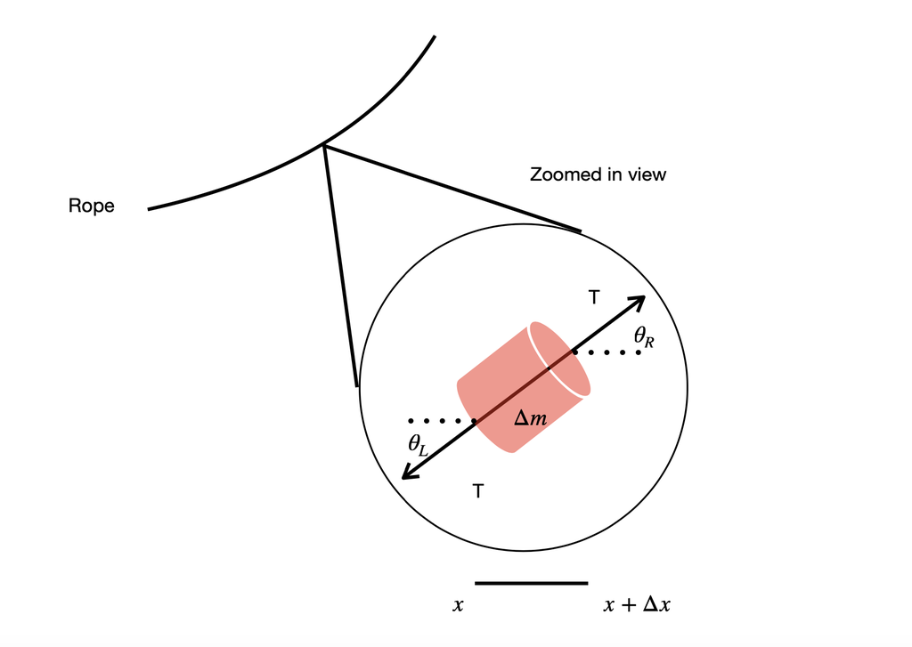

Zoomed in view of wave of a string.

```python
from IPython.display import Image, Markdown, display

display(Image("rope_figure.png"))
display(Markdown("""Zoomed in view of wave of a string."""))
```

## The Wave Equation

We want to derive the wave equation for a traveling wave on a rope. Our analysis requires a few assumptions:

- The tension $T$ in the rope is uniform.
- The amplitude is much smaller than the wavelength, which means all angles are small.

Our method to build up the wave equation will rely on Newton's second law. First we need an expression for the mass of a small segment of the rope. A small segment of mass $\Delta m$ is constructed by multiplying the total mass times the fraction of the segment's size to the total length:

\begin{align} \begin{split} \Delta m & = \text{total mass} \times \frac{\Delta x}{\text{total length}} \\ & = \frac{\text{total mass}} {\text{total length}} \Delta x \\ & = \mu \Delta x, \end{split} \end{align}

where $\mu$ is the linear mass density.

There is no change in motion in the $x$-direction—no part of the rope moves in the horizontal direction. Therefore, we need not worry about a force analysis in the $x$-direction.

The force equation in the $y$-direction, $\sum F_y = \Delta m a_y$, is

\begin{align} \begin{split} \Delta m ~a_y & = T\left(\sin \theta_R - \sin \theta_L \right) \\ \mu \Delta x \frac{\partial ^2 y}{\partial t^2} & = T \left(\sin \theta_R - \sin \theta_L\right). \end{split} \end{align}

Since the angles are small we have $\sin \theta \approx \tan \theta$, and we can describe $\tan \theta$ as the small change in the $y$-direction divided by the small change in the $x$-direction, or $\tan \theta \approx \partial y/\partial x$.

**Problem 14**

Show that

\begin{equation} \frac{\partial ^2 y}{\partial t^2} = \frac{T}{\mu} \frac{1}{\Delta x} \left[ \frac{\partial y}{\partial x} \Big|_{x + \Delta x} - \frac{\partial y}{\partial x} \Big|_{x} \right], \end{equation}

where $\Big|_{x + \Delta x}$ means that the function is evaluated at the point $x + \Delta x$.

**Solution**

Starting from the force equation:

\begin{equation} \mu \Delta x \frac{\partial ^2 y}{\partial t^2} = T \left(\sin \theta_R - \sin \theta_L\right). \end{equation}

Dividing both sides by $\mu \Delta x$:

\begin{equation} \frac{\partial ^2 y}{\partial t^2} = \frac{T}{\mu \Delta x} \left(\sin \theta_R - \sin \theta_L\right). \end{equation}

Using the small angle approximation $\sin \theta \approx \tan \theta \approx \frac{\partial y}{\partial x}$:

\begin{equation} \sin \theta_R \approx \frac{\partial y}{\partial x} \Big|_{x + \Delta x}, \quad \sin \theta_L \approx \frac{\partial y}{\partial x} \Big|_{x}. \end{equation}

Substituting these approximations:

\begin{equation} \frac{\partial ^2 y}{\partial t^2} = \frac{T}{\mu} \frac{1}{\Delta x} \left[ \frac{\partial y}{\partial x} \Big|_{x + \Delta x} - \frac{\partial y}{\partial x} \Big|_{x} \right]. \end{equation}

In the limit as $\Delta x \to 0$, the term on the right-hand side evaluates to the second partial derivative with respect to $x$:

\begin{equation} \lim_{\Delta x \to 0} \frac{1}{\Delta x} \left[ \frac{\partial y}{\partial x} \Big|_{x + \Delta x} - \frac{\partial y}{\partial x} \Big|_{x} \right] = \frac{\partial ^2 y}{\partial x^2}. \end{equation}

We now have

\begin{equation} \frac{\partial ^2 y}{\partial t^2} = \frac{T}{\mu} \frac{\partial ^2 y}{\partial x^2}, \end{equation}

which is the wave equation for a traveling wave on a rope.

In general, the wave equation is

\begin{equation} \frac{\partial ^2 y}{\partial t^2} = v^2 \frac{\partial ^2 y}{\partial x^2}, \end{equation}

where $v$ is the phase velocity of the wave. For a rope, $v = \sqrt{T/\mu}$.

**Problem 15**

Show by direct substitution into the wave equation that $y(x,t) = A\sin(kx - \omega t + \phi_0)$ is a solution to the wave equation, where $v = \omega/k$.

**Solution**

We need to compute the second partial derivatives of $y(x,t) = A\sin(kx - \omega t + \phi_0)$.

**Time derivatives:**

\begin{equation} \frac{\partial y}{\partial t} = -A\omega\cos(kx - \omega t + \phi_0). \end{equation}

\begin{equation} \frac{\partial^2 y}{\partial t^2} = -A\omega^2\sin(kx - \omega t + \phi_0). \end{equation}

**Space derivatives:**

\begin{equation} \frac{\partial y}{\partial x} = Ak\cos(kx - \omega t + \phi_0). \end{equation}

\begin{equation} \frac{\partial^2 y}{\partial x^2} = -Ak^2\sin(kx - \omega t + \phi_0). \end{equation}

**Substitute into the wave equation:**

\begin{equation} \frac{\partial^2 y}{\partial t^2} = v^2 \frac{\partial^2 y}{\partial x^2}. \end{equation}

\begin{equation} -A\omega^2\sin(kx - \omega t + \phi_0) = v^2 \left[-Ak^2\sin(kx - \omega t + \phi_0)\right]. \end{equation}

Dividing both sides by $-A\sin(kx - \omega t + \phi_0)$:

\begin{equation} \omega^2 = v^2 k^2. \end{equation}

Taking the square root:

\begin{equation} \omega = vk \quad \text{or} \quad v = \frac{\omega}{k}. \end{equation}

This confirms that $D(x,t) = A\sin(kx - \omega t + \phi_0)$ is a solution to the wave equation with phase velocity $v = \omega/k$.

## Wave on a Rope: Warm-Up Problem

**Problem 17**

(a) What is the tension $T$ in the rope?

(b) What is the linear mass density $\mu$ of the rope?

(c) What is the speed of waves traveling along the rope?

(d) If the vibrating source produces waves with a frequency of $f = 20$ Hz, what is the wavelength of the waves on the rope?

(e) How many complete wavelengths fit on the 8 m rope at this frequency?

**Hint for part (a)**

The tension in the rope equals the weight of the hanging mass (since we're neglecting the rope's weight compared to the hanging mass).

**Hint for part (c)**

Use the relationship $v = \sqrt{T/\mu}$ for wave speed on a rope.

**Hint for part (d)**

Use the wave equation $v = \lambda f$ to relate wavelength to frequency and wave speed.

**Solution**

**(a) Tension in the rope:**

The tension in the rope equals the weight of the hanging mass:

\begin{equation} T = mg = (5~\text{kg})(9.8~\text{m/s}^2) = 49~\text{N}. \end{equation}

**(b) Linear mass density:**

The linear mass density is the mass per unit length:

\begin{equation} \mu = \frac{M}{L} = \frac{1.6~\text{kg}}{8~\text{m}} = 0.2~\text{kg/m}. \end{equation}

**(c) Wave speed:**

The speed of waves on the rope is

\begin{equation} v = \sqrt{\frac{T}{\mu}} = \sqrt{\frac{49~\text{N}}{0.2~\text{kg/m}}} = \sqrt{245~\text{m}^2/\text{s}^2} = 15.7~\text{m/s}. \end{equation}

**(d) Wavelength:**

Using the wave equation $v = \lambda f$:

\begin{equation} \lambda = \frac{v}{f} = \frac{15.7~\text{m/s}}{20~\text{Hz}} = 0.785~\text{m} = 78.5~\text{cm}. \end{equation}

**(e) Number of wavelengths:**

The number of complete wavelengths that fit on the rope is

\begin{equation} n = \frac{L}{\lambda} = \frac{8~\text{m}}{0.785~\text{m}} = 10.2. \end{equation}

Approximately 10 complete wavelengths fit on the rope, with a partial wavelength at the end.

## Advanced Wave on a Rope Problem

**Problem 18** A uniform rope of total length $L = 12$ m and total mass $M = 2.4$ kg hangs vertically from a fixed support. The bottom end of the rope is free. At time $t = 0$, a transverse wave pulse is generated at the bottom of the rope and travels upward.

(a) Show that the tension in the rope varies with position. Find an expression for the tension $T(y)$ as a function of the distance $y$ measured upward from the bottom of the rope.

(b) Derive an expression for the wave speed $v(y)$ as a function of position $y$ along the rope.

(c) Calculate the time it takes for the wave pulse to travel from the bottom to the top of the rope.

(d) If instead the rope is placed horizontally on a frictionless table and one end is attached to an oscillator that produces waves with frequency $f = 60$ Hz, and the rope is held under a constant tension of $T = 100$ N, what is the wavelength of the waves on the rope?

(e) Now consider the original vertical rope configuration from parts (a)-(c). At what height $y$ from the bottom does the wave speed equal the wave speed calculated in part (d)?

**Hint for part (a)**

Consider a small segment of rope at height $y$. The tension at this point must support the weight of all the rope below it.

**Hint for part (b)**

Use the relationship $v = \sqrt{T/\mu}$ where $\mu$ is the linear mass density. Remember that $T$ depends on $y$ from part (a).

**Hint for part (c)**

Since the wave speed varies with position, you cannot simply use $t = L/v$. Instead, set up the differential relationship $dy = v(y) dt$ and integrate.

**Hint for part (d)**

This is a standard wave problem with constant tension. Use $v = \sqrt{T/\mu}$ and $\lambda = v/f$.

**Hint for part (e)**

Set the expression for $v(y)$ from part (b) equal to the constant wave speed from part (d) and solve for $y$.

**Solution**

**(a) Tension as a function of position:**

Consider a point at height $y$ from the bottom. The tension at this point must support the weight of the rope below it. The mass of rope below height $y$ is

\begin{equation} m(y) = \frac{M}{L} y = \mu y, \end{equation}

where $\mu = M/L$ is the linear mass density. The tension is

\begin{equation} T(y) = m(y)g = \mu g y = \frac{Mg}{L} y. \end{equation}

Substituting values:

\begin{equation} T(y) = \frac{(2.4~\text{kg})(9.8~\text{m/s}^2)}{12~\text{m}} y = (1.96~\text{N/m}) y. \end{equation}

**(b) Wave speed as a function of position:**

The wave speed on a rope is given by

\begin{equation} v = \sqrt{\frac{T}{\mu}}. \end{equation}

Substituting $T(y) = \mu g y$:

\begin{equation} v(y) = \sqrt{\frac{\mu g y}{\mu}} = \sqrt{gy}. \end{equation}

This is independent of the rope's mass or length—it depends only on $g$ and position $y$.

\begin{equation} v(y) = \sqrt{(9.8~\text{m/s}^2) y} = (3.13~\text{m}^{1/2}\text{/s}) \sqrt{y}. \end{equation}

**(c) Time for wave to travel from bottom to top:**

The wave speed varies with position, so we must integrate. From $v = dy/dt$:

\begin{equation} dt = \frac{dy}{v(y)} = \frac{dy}{\sqrt{gy}}. \end{equation}

Integrating from $y = 0$ to $y = L$:

\begin{equation} t = \int_0^L \frac{dy}{\sqrt{gy}} = \frac{1}{\sqrt{g}} \int_0^L y^{-1/2} dy. \end{equation}

\begin{equation} t = \frac{1}{\sqrt{g}} \left[ 2y^{1/2} \right]_0^L = \frac{2\sqrt{L}}{\sqrt{g}} = 2\sqrt{\frac{L}{g}}. \end{equation}

Substituting values:

\begin{equation} t = 2\sqrt{\frac{12~\text{m}}{9.8~\text{m/s}^2}} = 2\sqrt{1.224~\text{s}^2} = 2(1.106~\text{s}) = 2.21~\text{s}. \end{equation}

**(d) Wavelength on horizontal rope:**

First, find the linear mass density:

\begin{equation} \mu = \frac{M}{L} = \frac{2.4~\text{kg}}{12~\text{m}} = 0.2~\text{kg/m}. \end{equation}

The wave speed with constant tension is:

\begin{equation} v = \sqrt{\frac{T}{\mu}} = \sqrt{\frac{100~\text{N}}{0.2~\text{kg/m}}} = \sqrt{500~\text{m}^2\text{/s}^2} = 22.4~\text{m/s}. \end{equation}

The wavelength is:

\begin{equation} \lambda = \frac{v}{f} = \frac{22.4~\text{m/s}}{60~\text{Hz}} = 0.373~\text{m} = 37.3~\text{cm}. \end{equation}

**(e) Height where wave speeds are equal:**

Set $v(y) = v_{\text{horizontal}}$:

\begin{equation} \sqrt{gy} = 22.4~\text{m/s}. \end{equation}

Squaring both sides:

\begin{equation} gy = (22.4~\text{m/s})^2 = 502~\text{m}^2\text{/s}^2. \end{equation}

\begin{equation} y = \frac{502~\text{m}^2\text{/s}^2}{9.8~\text{m/s}^2} = 51.2~\text{m}. \end{equation}

Since $y = 51.2$ m exceeds the rope length of $L = 12$ m, **the wave speed on the vertical rope never reaches the wave speed from part (d)**. The maximum wave speed on the vertical rope occurs at the top ($y = L = 12$ m):

\begin{equation} v_{\text{max}} = \sqrt{gL} = \sqrt{(9.8)(12)} = 10.8~\text{m/s}, \end{equation}

which is less than the 22.4 m/s from part (d).